# Problem Set 4

**For these questions, use your project data set that you have chosen for the Project assignment or any test data set other than those used in class lectures or labs.**

**This will be the first part of your semester project.**

**If you choose not to use Quarto or R Markdown, your results need to be similarly formatted to the output of a rendered Quarto or knitted R Markdown document. Readability and format matter.**

```r
demonstration_data <- read.csv("demonstration_data.csv")
head(demonstration_data)
```

```
     X country_name country_text_id country_id v2x_delibdem v2x_egaldem
1  230       Mexico             MEX          3        0.467       0.375
2  353     Suriname             SUR          4        0.625       0.564
3  587       Sweden             SWE          5        0.872       0.836
4  812  Switzerland             CHE          6        0.880       0.839
5  933        Ghana             GHA          7        0.634       0.549
6 1056 South Africa             ZAF          8        0.633       0.472
  v2x_libdem v2x_partipdem v2x_polyarchy v2xcl_prpty v2clprptyw v2clprptym
1      0.448         0.426         0.671       0.818      1.539      1.667
2      0.624         0.484         0.764       0.855      1.817      1.802
3      0.885         0.659         0.916       0.941      2.336      2.716
4      0.872         0.812         0.910       0.938      2.613      2.308
5      0.630         0.387         0.739       0.868      1.819      1.966
6      0.620         0.480         0.731       0.757      1.077      1.531
  v2exl_legitideol v2exl_legitlead v2clacjstm v2clacjstw
1           -0.514          -0.430     -0.522     -0.397
2            0.003           0.790      1.296      1.331
3           -1.803          -2.937      2.706      3.069
4           -2.884          -2.135      3.238      3.428
5           -1.343          -0.864      2.062      1.727
6            0.058          -0.063      1.821      1.676
```

1. What is the source of your data set? (Where did you get it?)

Answer: VDem (Varieties of Democracy) Project

2. How did the source obtain the data? (Survey, experiment, observation/collection)

Answer: The V-Dem project collects data through expert surveys and observation.

3. What are your two main variables of interest (x and y)? *If you are considering cause and effect, x is the cause and y is the effect*

Answer: x - v2x_partipdem (Participatory Democracy Index) y - v2clacjstw (Access to Justice for Women Index)

4. How many observations (n) are there? *You can use length() to count number or you can use View() to look at the data and look for the number of rows. You can also use as.numeric(length()) to create an object with the number of observations, n, for later use.*

**For both your x and y variables:**

n for x: 179

n for y: 179

5. What is the median?

```r
median(demonstration_data$v2x_partipdem)
```

```
[1] 0.33
```

```r
median(demonstration_data$v2clacjstw)
```

```
[1] 0.914
```

**median of x:** 0.33

**median of y:** 0.914

6. What is the mean?

```r
mean(demonstration_data$v2x_partipdem)
```

```
[1] 0.3375642
```

```r
mean(demonstration_data$v2clacjstw)
```

```
[1] 0.8239832
```

mean of x: 0.3375642

mean of y: 0.8239832

7. What are the sample variance and sample standard deviation?

*Note: We will use sample variance for project data because in most cases your data sets are only a sample not the full population.*

```r
var(demonstration_data$v2x_partipdem)
```

```
[1] 0.03930313
```

```r
var(demonstration_data$v2clacjstw)
```

```
[1] 1.690575
```

```r
sd(demonstration_data$v2x_partipdem)
```

```
[1] 0.1982502
```

```r
sd(demonstration_data$v2clacjstw)
```

```
[1] 1.300221
```

sample variance of x: 0.03930313

sample standard deviation of y: 1.300221

8. What are the minimum and maximum?

```r
summary(demonstration_data$v2x_partipdem)
```

```
   Min. 1st Qu.  Median    Mean 3rd Qu.    Max.
 0.0090  0.1680  0.3300  0.3376  0.4815  0.8120
```

```r
summary(demonstration_data$v2clacjstw)
```

```
   Min. 1st Qu.  Median    Mean 3rd Qu.    Max.
-2.5770 -0.1185  0.9140  0.8240  1.7295  3.9320
```

x minimum: 0.0090 x maximum: 0.8120

9. What are the first and third quartiles?

x first quartile: 0.1680 x third quartile: 0.4815

y first quartile: -0.1185 y third quartile: 1.7295

10. Plot a histogram of the x variable. (2 points)

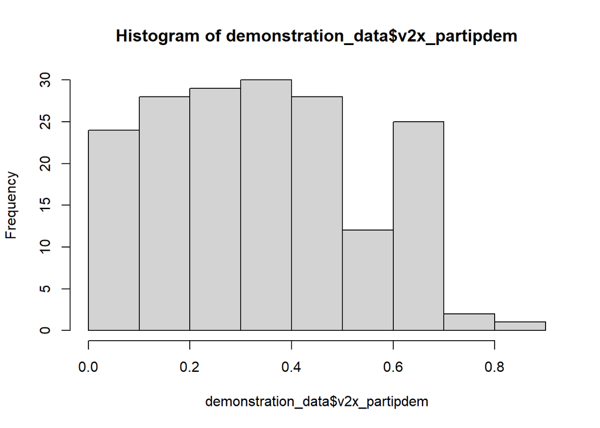

```r
hist(demonstration_data$v2x_partipdem)
```

11. Plot a histogram of the y variable. (2 points)

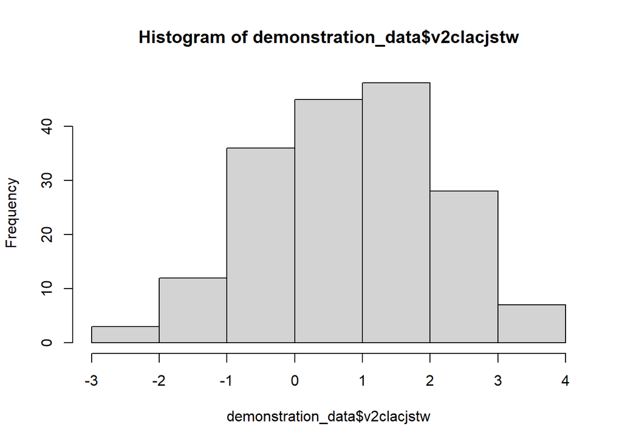

```r
hist(demonstration_data$v2clacjstw)
```